# RNA-Seq_A-to-I

### DESeq2 to test the differential methylation between the spliced mRNA and pre-mRNA

```r
# Load input data
test.list <- readRDS("/gpfs/work/bio/haozhewang17/data/VeloRM_data/RNA-Seq_A-to-I/pre_process/test.list.rds")

# Extract different parts of the data
spliced.meth.test <- test.list[[1]]  # Methylated spliced data
spliced.unmeth.test <- test.list[[2]]  # Unmethylated spliced data
unspliced.meth.test <- test.list[[3]]  # Methylated unspliced data
unspliced.unmeth.test <- test.list[[4]]  # Unmethylated unspliced data

# Set random seed for reproducibility
set.seed(42)

# Record start time
start_time <- Sys.time()

# Load DESeq2 package
library(DESeq2)

# Define DESeq2 differential expression analysis function
DESeq2_test <- function(meth_control, meth_test, unmeth_control, unmeth_test) {
  # Convert input data to data frames
  meth_control <- data.frame(meth_control)
  meth_test <- data.frame(meth_test)
  unmeth_control <- data.frame(unmeth_control)
  unmeth_test <- data.frame(unmeth_test)

  # Function to calculate size factor
  sizeFactor <- function(data) {
    # Ensure data is not less than 0
    data <- as.matrix(data)

    # Log-transform the data
    log_data <- log(data)
    log_data[is.infinite(log_data)] <- NA
    log_mean <- rowMeans(log_data, na.rm = TRUE)
    log_s <- log_data - log_mean

    # Calculate size factor
    s_size <- exp(apply(log_s, 2, function(x) median(x, na.rm = TRUE)))
    return(s_size)
  }

  # Calculate size factors for spliced and unspliced data
  spliced_total <- meth_control + unmeth_control
  unspliced_total <- meth_test + unmeth_test

  spliced_size_factor <- sizeFactor(spliced_total)
  unspliced_size_factor <- sizeFactor(unspliced_total)

  # Get the number of control and test samples
  num_control <- dim(unmeth_control)[2]
  num_test <- dim(unmeth_test)[2]

  # Combine all data
  counts <- cbind(meth_control, meth_test, unmeth_control, unmeth_test)

  # Design the experiment matrix
  design = data.frame(
    Trt = rep(c(rep("control", num_control), rep("test", num_test)), 2),
    Meth = c(rep("meth", (num_control + num_test)), rep("unmeth", (num_control + num_test)))
  )

  # Define the model
  model = ~ Meth + Trt + Meth:Trt

  # Create DESeqDataSet object
  dds <- DESeqDataSetFromMatrix(countData = counts,
                                colData = design,
                                design = model)

  # Set size factors
  sizeFactors(dds) = rep(c(spliced_size_factor, unspliced_size_factor), 2)

  # Perform differential expression analysis
  dds <- DESeq(dds, test = "Wald")

  # Extract results
  res = DESeq2::results(dds, name = "Methunmeth.Trttest", cooksCutoff = FALSE)

  return(res)
}

# Call the function to perform differential expression analysis
result <- DESeq2_test(spliced.meth.test, unspliced.meth.test, spliced.unmeth.test, unspliced.unmeth.test)

# Record end time
end_time <- Sys.time()

# Print the runtime
print(end_time - start_time)


# Save the results
saveRDS(result, "/gpfs/work/bio/haozhewang17/data/VeloRM_data/RNA-Seq_A-to-I/pre_process/res_DESeq2.rds")
```

We will get the following data in VeloRM_data/RNA-Seq_A-to-I/pre_process

Processed data:

test_list: the test cell reads counts (spliced_meth_test,spliced_unmeth_test,pre_meth_test,pre_unmeth_test, isoform_meth_test,isoform_unmeth_test)

control_list: NULL

res_preprocess: the list processed by VeloRM

res_DESeq2: the DESeq2 results

## analysis

### Overall reads counts

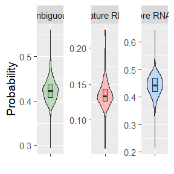

```r
library(ggplot2)
library(dplyr)
library(tidyr)

counts_data <- read.csv("D:/data/VeloRM_data/RNA-Seq_A-to-I/origin/bam_read_counts.csv",
                       header = TRUE,  # Assumes first row contains column names
                       stringsAsFactors = FALSE)  # Prevents automatic conversion to factors

# View the first few rows

counts_data_sum <- apply(counts_data,1,function(x) sum(as.numeric(x[2:4])))
isoform_prop <- as.numeric(counts_data[,2])/counts_data_sum
spliced_prop <- as.numeric(counts_data[,3])/counts_data_sum
pre_prop <- as.numeric(counts_data[,4])/counts_data_sum

df <- data.frame(
  `mature RNA` = spliced_prop,
  `pre RNA` = pre_prop,
  `ambiguous` = isoform_prop,
  check.names = FALSE
)
df_long <- pivot_longer(df, cols = everything(),
                       names_to = "Type",
                       values_to = "Probability")

box_plot <- ggplot(df_long, aes(x = "", y = Probability, fill = Type)) +
    geom_violin(alpha = 0.6, width = 0.7) +
    geom_boxplot(width = 0.2, alpha = 0.8,
                 outlier.shape = NA,
                 coef = 0) +
    facet_wrap(~Type, scales = "free_y", ncol = 3) +
    labs(
        title = NULL,
        x = NULL,
        y = "Probability"
    ) +
    # Use theme_gray() which is the default ggplot2 theme
    theme_gray(base_size = 14)  +
    scale_fill_manual(
        values = c("mature RNA" = "#FF9999",
                   "pre RNA" = "#99CCFF",
                   "ambiguous" = "#99CC99"),
        breaks = c("mature RNA", "pre RNA", "ambiguous")
    )+
  theme(
    legend.position = "none"
  )

box_plot
```

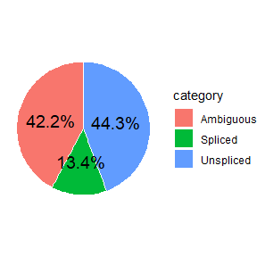

```r
# Assuming plot_data is defined as you provided
plot_data <- data.frame(
  category = c("Ambiguous","Spliced", "Unspliced"),
  proportion = c(sum(counts_data[,2]),sum(counts_data[,3]), sum(counts_data[,4]))
)

# Create pie chart
pie_chart <- ggplot(plot_data, aes(x = "", y = proportion, fill = category)) +
  geom_bar(stat = "identity", width = 1, color = "white") + # white border between slices
  coord_polar(theta = "y") + # convert barplot to pie
  geom_text(aes(label = paste0(round(proportion / sum(proportion) * 100, 1), "%")),
            position = position_stack(vjust = 0.5), size = 5) + # add percentage labels
  labs(title = NULL, x = NULL, y = NULL) +
  theme_void() + # remove background, axes, grid
  theme(legend.position = "right",
        plot.title = element_text(hjust = 0.5))

pie_chart
```

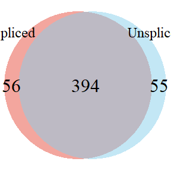

```r
res_preprocess <- readRDS("D:/data/VeloRM_data/RNA-Seq_A-to-I/pre_process/res_preprocess.rds")
spliced_index <- which(res_preprocess[["spliced_methylation_M_value_meta"]]>=1)
unspliced_index <- which(res_preprocess[["unspliced_methylation_M_value_meta"]]>=1)


spliced_index_l <- length(spliced_index)
unspliced_index_l <- length(unspliced_index)
intersect_l <- length(intersect(spliced_index,unspliced_index))

library(VennDiagram)
grid.newpage()
venn <-draw.pairwise.venn(
  area1 = spliced_index_l,
  area2 = unspliced_index_l,
  cross.area = intersect_l,
  category = c("Spliced", "Unspliced"),
  fill = c("#E74C3C","skyblue"),
  alpha = 0.5,
  lty = "blank",
  cex = 2,
  cat.cex = 1.5
)
```

### splicing jucntion distance

```r
library(GenomicRanges)
library(rtracklayer)
library(dplyr)
library(tidyr)

snp <- readRDS("D:/data/VeloRM_data/RNA-Seq_A-to-I/pre_process/SNP_1019.rds")
snp_pos <- snp@ranges@start
snp_chr_length <- snp@seqnames@lengths
snp_chr_seq <- snp@seqnames@values
snp_chr <- as.character(rep(snp_chr_seq,snp_chr_length))
snp_strand <- snp@elementMetadata@listData[["transcript_strand"]]
snp_data <- as.data.frame(cbind(snp_chr,snp_pos,snp_strand))
snp_data$snp_pos <- as.numeric(snp_data$snp_pos)




# Read the GTF file from Ensembl
gtf_file <- "D:/data/VeloRM_data/RNA-Seq_A-to-I/origin/gencode.vM33.annotation.gtf"
gtf_data <- import(gtf_file)

# Filter for exons
exons <- gtf_data[gtf_data$type == "exon"]

# Convert to data frame
exons_df <- data.frame(
chr = as.character(seqnames(exons)),
start = start(exons),
end = end(exons),
strand = as.character(strand(exons)),
gene_id = mcols(exons)$gene_id,
transcript_id = mcols(exons)$transcript_id
)

# Sort exons by transcript and position
exons_df <- exons_df %>%
arrange(transcript_id, chr, start)

# Extract splicing junctions using intron boundaries
junctions <- exons_df %>%
group_by(transcript_id) %>%
arrange(if_else(strand == "+", start, -start)) %>%  # Sort based on strand
mutate(
  donor_site = end,                # End of the upstream exon
  acceptor_site = lead(start)      # Start of the downstream exon
) %>%
filter(!is.na(acceptor_site)) %>%   # Remove the last exon (no downstream exon)
ungroup() %>%
select(chr, donor_site, acceptor_site, gene_id, transcript_id, strand)


junctions_unique <- junctions %>%
 distinct(chr, donor_site, acceptor_site, .keep_all = TRUE)



junctions_long <- junctions_unique %>%
 pivot_longer(cols = c(donor_site, acceptor_site),
              names_to = "site_type",
              values_to = "site_position") %>%
 select(chr, site_position, site_type, gene_id, transcript_id, strand)



# Calculate distance from each SNP to the nearest junction (matching chr and strand)
snp_with_distance <- snp_data %>%
 rowwise() %>%
 mutate(
   nearest_junction_distance = min(
     abs(junctions_long$site_position[junctions_long$chr == snp_chr & junctions_long$strand == snp_strand] - snp_pos),
     na.rm = TRUE
   )
 )


# get normal chr
standard_chromosomes <- paste0("chr", c(1:22, "X", "Y"))

# get the exon with the normal chr
exons_filtered <- exons[seqnames(exons) %in% standard_chromosomes]



# calculate the distance
exon_lengths <- width(exons_filtered)

# calculate the prob
prob_weights <- exon_lengths / sum(exon_lengths)

# random sample
set.seed(123)


#random_distances_list <- list()

#for (i in 1:10){
 selected_exons <- sample(seq_along(exons_filtered), size = 1019, replace = TRUE, prob = prob_weights)
 # choose the site in the select the exons
 random_positions <- start(exons[selected_exons]) +
   floor(runif(1019, min = 0, max = exon_lengths[selected_exons]))

 # create the data frame
 random_sites <- data.frame(
   chr = as.character(seqnames(exons[selected_exons])),
   position = random_positions,
   strand = as.character(strand(exons[selected_exons]))
 )


 # Calculate distance from each SNP to the nearest junction (matching chr and strand)
 random_sites_with_distance <- random_sites %>%
   rowwise() %>%
   mutate(
     nearest_junction_distance = min(
       abs(junctions_long$site_position[junctions_long$chr == chr & junctions_long$strand == strand] - position),
       na.rm = TRUE
     )
   )
 random_distances_list  <- random_sites_with_distance$nearest_junction_distance
#}



random_distances_df <- data.frame(
 distance = random_distances_list,
 group = "Random"
)

# merge the data frame
real_distances_df <- data.frame(
 distance = snp_with_distance$nearest_junction_distance,
 group = "Real"
)


all_distances_df <- bind_rows(random_distances_df, real_distances_df)
group_order <- c("Real","Random")
all_distances_df$group <- factor(all_distances_df$group, levels = group_order)
library(ggplot2)
#  Boxplot
plot <- ggplot(all_distances_df, aes(x = group, y = log10(distance+1), fill = group)) +
 geom_violin(trim = FALSE, alpha = 0.5) +
 geom_boxplot(width = 0.1, outlier.shape = NA)+
 scale_fill_manual(values = c("red",rep("lightblue", 10))) +
 labs(title = NULL,
      x = NULL,
      y = "log10(Distance (bp)+1)") +
 theme_minimal() +
 theme(
       plot.title = element_text(hjust = 0.5),
       legend.position = "none")+coord_cartesian(ylim = c(0,7))


saveRDS(all_distances_df,"D:/data/VeloRM_data/RNA-Seq_A-to-I/results/splicing_junction_analysis/all_distances_df.rds")
```

#### vis

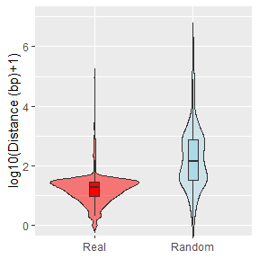

```r
 all_distances_df <- readRDS("D:/data/VeloRM_data/RNA-Seq_A-to-I/results/splicing_junction_analysis/all_distances_df.rds")

library(ggplot2)
#  Boxplot
plot <- ggplot(all_distances_df, aes(x = group, y = log10(distance+1), fill = group)) +
 geom_violin(trim = FALSE, alpha = 0.5) +
 geom_boxplot(width = 0.1, outlier.shape = NA)+
 scale_fill_manual(values = c("red",rep("lightblue", 10))) +
 labs(title = NULL,
      x = NULL,
      y = "log10(Distance (bp)+1)") +
 theme_grey() +
 theme(plot.title = element_text(hjust = 0.5),
       legend.position = "none")+coord_cartesian(ylim = c(0,7))
plot
```

### read the DESeq2 results

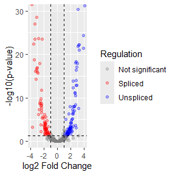

```r
library(ggplot2)
library(dplyr)
library(tidyr)

res_DESeq2 <- readRDS("D:/data/VeloRM_data/RNA-Seq_A-to-I/pre_process/res_DESeq2.rds")


log2FC <-res_DESeq2@listData[["log2FoldChange"]]
pvals <- res_DESeq2@listData[["pvalue"]]

plot_data <- data.frame(log2FC = log2FC,
                       pvalue = pvals,
                       neg_log10_p = -log10(pvals))


volcano_plot_DESeq2 <- ggplot(plot_data, aes(x = log2FC, y = neg_log10_p)) +
  # Add light gray background for -1 < log2FC < 1 (non-significant FC region)
  annotate("rect", xmin = -1, xmax = 1, ymin = 0, ymax = 30,
           fill = "gray90", alpha = 0.3) +

  # Color points based on significance and log2FC:
  # - Red: log2FC > 1 & p < 0.05 (significantly up-regulated)
  # - Blue: log2FC < -1 & p < 0.05 (significantly down-regulated)
  # - Gray: Not significant or |log2FC| ≤ 1
  geom_point(aes(color = case_when(
    log2FC > 1 & pvalue < 0.05 ~ "Unspliced",
    log2FC < -1 & pvalue < 0.05 ~ "Spliced",
    TRUE ~ "Not significant"
  )), alpha = 0.3) +

  # Manual color scale (red, blue, gray)
  scale_color_manual(
    values = c(
      "Spliced" = "red",
      "Unspliced" = "blue",
      "Not significant" = "gray50"
    ),
    name = "Regulation"  # Legend title
  ) +

  # Add dashed lines for thresholds:
  # - Vertical: log2FC = ±1
  # - Horizontal: p-value = 0.05 (-log10(0.05) ≈ 1.3)
  geom_vline(xintercept = c(-1, 1), linetype = "dashed", color = "black") +
  geom_hline(yintercept = -log10(0.05), linetype = "dashed", color = "black") +

  # Axis labels and theme
  labs(
    x = "log2 Fold Change",
    y = "-log10(p-value)",
    title = NULL
  ) +
   theme_grey() +
   # Set axis limits (zoomed-in view)
   coord_cartesian(ylim = c(0, 30),xlim = c(-4, 4))
volcano_plot_DESeq2
```

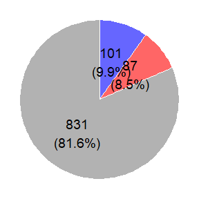

```r
n_unspliced <- length(which(log2FC >= 1 & pvals <= 0.05))
n_spliced <- length(which(log2FC <= -1 & pvals <= 0.05))
n_nonsig <- sum(pvals > 0.05 | (log2FC > -1 & log2FC < 1))

total <- n_unspliced + n_spliced + n_nonsig
Percentage <- round(c(n_unspliced, n_spliced, n_nonsig) / total * 100, 1)

df <- data.frame(
  Category = c("Unspliced", "Spliced", "Insignificant"),
  Count = c(n_unspliced, n_spliced, n_nonsig)
)



pie_chart_DESeq2 <- ggplot(df, aes(x = "", y = Count, fill = Category)) +
  geom_bar(stat = "identity", width = 1, color = "white",alpha=0.6) +
  coord_polar("y", start = 0) +
  geom_text(aes(label = paste0(Count, "\n(", Percentage, "%)")),
            position = position_stack(vjust = 0.5), size = 5) +
  scale_fill_manual(values = c("Unspliced" = "blue", "Spliced" = "red","Insignificant"="gray50")) +
  labs(
    title = NULL,
    x = NULL,
    y = NULL
  ) +
  theme_void() +
  theme(
    legend.position = "none"
  )

pie_chart_DESeq2
```

### meth density

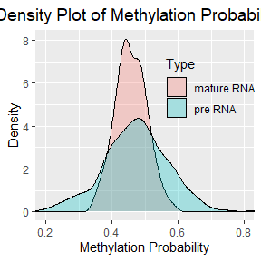

```r
# Load input data
test.list <- readRDS("D:/data/VeloRM_data/RNA-Seq_A-to-I/pre_process/test.list.rds")

# Extract different parts of the data
spliced.meth.test <- test.list[[1]]  # Methylated spliced data
spliced.unmeth.test <- test.list[[2]]  # Unmethylated spliced data
unspliced.meth.test <- test.list[[3]]  # Methylated unspliced data
unspliced.unmeth.test <- test.list[[4]]  # Unmethylated unspliced data
isoform.meth.test <- test.list[[5]]  # Methylated isoform data
isoform.unmeth.test <- test.list[[6]]  # Unmethylated isoform data





spliced.meth.sum.cell <- apply(spliced.meth.test,2,sum)#,apply(spliced.meth.control,2,sum))
spliced.unmeth.sum.cell <- apply(spliced.unmeth.test,2,sum)#,apply(spliced.unmeth.control,2,sum))
unspliced.meth.sum.cell <- apply(unspliced.meth.test,2,sum)#,apply(unspliced.meth.control,2,sum))
unspliced.unmeth.sum.cell <- apply(unspliced.unmeth.test,2,sum)#,apply(unspliced.unmeth.control,2,sum))
isoform.meth.sum.cell <- apply(isoform.meth.test,2,sum)#,apply(unspliced.meth.control,2,sum))
isoform.unmeth.sum.cell <- apply(isoform.unmeth.test,2,sum)#,apply(unspliced.unmeth.control,2,sum))

spliced.sum.cell <- spliced.meth.sum.cell + spliced.unmeth.sum.cell
unspliced.sum.cell <- unspliced.meth.sum.cell + unspliced.unmeth.sum.cell
isoform.sum.cell <- isoform.meth.sum.cell + isoform.unmeth.sum.cell

spliced.prob.cell <- spliced.sum.cell/(spliced.sum.cell+unspliced.sum.cell+isoform.sum.cell)
unspliced.prob.cell <- unspliced.sum.cell/(spliced.sum.cell+unspliced.sum.cell+isoform.sum.cell)
isoform.prob.cell <- isoform.sum.cell/(spliced.sum.cell+unspliced.sum.cell+isoform.sum.cell)


spliced.cell.prob <- spliced.meth.sum.cell/(spliced.unmeth.sum.cell+spliced.meth.sum.cell)
unspliced.cell.prob <- unspliced.meth.sum.cell/(unspliced.unmeth.sum.cell+unspliced.meth.sum.cell)

df <- data.frame(
  Probability = c(spliced.cell.prob, unspliced.cell.prob),
  Type = rep(c("mature RNA", "pre RNA"),
             c(length(spliced.cell.prob), length(unspliced.cell.prob)))
)

# Create the density plot
ggplot(df, aes(x = Probability, fill = Type)) +
  geom_density(alpha = 0.3) +
  labs(title = "Density Plot of Methylation Probabilities",
       x = "Methylation Probability",
       y = "Density") +
  theme_grey()+
  theme(
    plot.title = element_text(hjust = 0.5, size = 14),
    legend.position = c(0.8, 0.7),
    legend.background = element_blank())+coord_cartesian(xlim=c(0.2,0.8))
```

### Regulatory mechanisms

#### Finding sites where methylation levels are high in pre-mRNA but low in spliced mRNA, as well as sites where methylation levels are high in spliced mRNA but low in pre-mRNA.

```r
library(TxDb.Mmusculus.UCSC.mm39.knownGene)
```

```r
library(MetaTX)
library(ggplot2)
library(dplyr)
res_preprocess <- readRDS("D:/data/VeloRM_data/RNA-Seq_A-to-I/pre_process/res_preprocess.rds")
spliced_methylation_M_value_meta <- res_preprocess$spliced_methylation_M_value_meta
unspliced_methylation_M_value_meta <- res_preprocess$unspliced_methylation_M_value_meta



index_pre_high_spliced_low <- which(unspliced_methylation_M_value_meta-spliced_methylation_M_value_meta>=1)
index_spliced_high_pre_low <- which(spliced_methylation_M_value_meta-unspliced_methylation_M_value_meta>=1)
```

#### metaTX plot

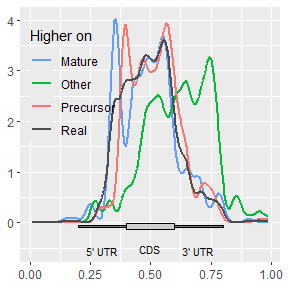

```r
intersect_pre_dominate <-index_pre_high_spliced_low

intersect_spliced_dominate <-index_spliced_high_pre_low

reads_counts_isoform <- readRDS("D:/data/VeloRM_data/RNA-Seq_A-to-I/pre_process/reads_counts_isoform.rds")
reads_counts_pre <- readRDS("D:/data/VeloRM_data/RNA-Seq_A-to-I/pre_process/reads_counts_pre.rds")
reads_counts_spliced <- readRDS("D:/data/VeloRM_data/RNA-Seq_A-to-I/pre_process/reads_counts_spliced.rds")
reads_counts_meth <- as.data.frame(lapply(reads_counts_isoform,function(x)x[["methylated_reads"]]))+
  as.data.frame(lapply(reads_counts_pre,function(x)x[["methylated_reads"]]))+
  as.data.frame(lapply(reads_counts_spliced,function(x)x[["methylated_reads"]]))

reads_counts_unmeth <- as.data.frame(lapply(reads_counts_isoform,function(x)x[["unmethylated_reads"]]))+
  as.data.frame(lapply(reads_counts_pre,function(x)x[["unmethylated_reads"]]))+
  as.data.frame(lapply(reads_counts_spliced,function(x)x[["unmethylated_reads"]]))

reads_counts_M_overall <- ((rowSums(reads_counts_meth)+1e-7)/(rowSums(reads_counts_unmeth)+rowSums(reads_counts_meth)+1e-7))


index_not_dominate <- order(reads_counts_M_overall,decreasing = TRUE)[1:500]

# metaTX

SNP_all <- readRDS("D:/data/VeloRM_data/RNA-Seq_A-to-I/origin/SNP_all.rds")
SNP_1019 <- readRDS("D:/data/VeloRM_data/RNA-Seq_A-to-I/pre_process/SNP_1019.rds")
txdb <- TxDb.Mmusculus.UCSC.mm39.knownGene


SNP_intersect_pre_dominate <- SNP_1019[intersect_pre_dominate]
SNP_intersect_spliced_dominate <- SNP_1019[intersect_spliced_dominate]
SNP_intersect_not_dominate <- SNP_all[index_not_dominate]
SNP_background <- SNP_1019

SNP_to_exclude <- c(SNP_intersect_pre_dominate, SNP_intersect_spliced_dominate)

library(GenomicRanges)
hits <- findOverlaps(SNP_intersect_not_dominate, SNP_to_exclude)

if(length(hits)!=0){
  SNP_intersect_not_dominate<- SNP_intersect_not_dominate[-queryHits(hits)]
}

remap_results_pre_dominate <- remapCoord(features = SNP_1019[intersect_pre_dominate], txdb = txdb)
remap_results_spliced_dominate <- remapCoord(features = SNP_1019[intersect_spliced_dominate], txdb = txdb)
remap_results_not_dominate <- remapCoord(features = SNP_intersect_not_dominate, txdb = txdb)
remap_results_background <- remapCoord(features = SNP_background, txdb = txdb)


# Step 2: Create plots for each subset
plot_pre_dominate <- directPlot(remap_results_pre_dominate)
plot_spliced_dominate <- directPlot(remap_results_spliced_dominate)
plot_not_dominate <- directPlot(remap_results_not_dominate)
plot_background <- directPlot(remap_results_background)

data_a <- ggplot_build(plot_pre_dominate)$data[[1]] %>% mutate(Group = "Precursor")
data_b <- ggplot_build(plot_spliced_dominate)$data[[1]] %>% mutate(Group = "Mature")
data_c <- ggplot_build(plot_not_dominate)$data[[1]] %>% mutate(Group = "Other")
data_d <- ggplot_build(plot_background)$data[[1]] %>% mutate(Group = "Real")

# Combine all datasets
combined_data <- bind_rows(data_a, data_b, data_c, data_d)#, data_intersect)

region_rects <- data.frame(
    xmin = c(0.2, 0.4, 0.6),  # Start positions of each region
    xmax = c(0.4, 0.6, 0.8),  # End positions of each region
    ymin = min(combined_data$y, na.rm = TRUE) - 0.1,  # Adjust below data range
    ymax = min(combined_data$y, na.rm = TRUE) - 0.05, # Slightly higher to make room
    Region = c("5' UTR", "CDS", "3' UTR")
)

# Calculate the height of 5' UTR and 3' UTR regions
utr_height <- region_rects$ymax[region_rects$Region == "5' UTR"] - region_rects$ymin[region_rects$Region == "5' UTR"]

# Increase the height of CDS region by 20% (can be adjusted as needed)
cds_height <- utr_height * 2 # Increase height by 30%

# Set ymin and ymax for CDS so that it is centered with respect to 5' UTR and 3' UTR
region_rects$ymin[region_rects$Region == "CDS"] <- region_rects$ymin[region_rects$Region == "CDS"] - 0.5*utr_height  # Decrease ymin for CDS
region_rects$ymax[region_rects$Region == "CDS"] <- region_rects$ymin[region_rects$Region == "CDS"] + cds_height  # Increase ymax for CDS


compare_metaTX_plot <-ggplot(combined_data, aes(x = x, y = y, color = Group))+
  geom_line(size=1)+
    # Add region highlights using geom_rect, with consistent positioning across all facets
    geom_rect(data = region_rects, aes(xmin = xmin, xmax = xmax, ymin = ymin, ymax = ymax, fill = Region),
              inherit.aes = FALSE, color = "black", alpha = 0.4,
              linewidth = 0.5) +  # Default linewidth for all regions
    # Set fill for CDS region to grey (lighter than black)
    geom_rect(data = subset(region_rects, Region == "CDS"), aes(xmin = xmin, xmax = xmax, ymin = ymin, ymax = ymax),
              inherit.aes = FALSE, fill = "grey", color = "black", alpha = 0.4, linewidth = 0.5) +  # Grey fill for CDS
    # Adjust 5' UTR and 3' UTR fills to a very dark grey, closer to black
    geom_rect(data = subset(region_rects, Region != "CDS"), aes(xmin = xmin, xmax = xmax, ymin = ymin, ymax = ymax,
                                                                fill = factor(Region, levels = c("5' UTR", "3' UTR"))),
              inherit.aes = FALSE, color = "black", alpha = 0.3, linewidth = 0.5) +
    scale_fill_manual(values = c("5' UTR" = grey(0.15),  # Very dark grey for 5' UTR, closer to black
                                "CDS" = "grey",           # Grey for CDS
                                "3' UTR" = grey(0.15))) +  # Very dark grey for 3' UTR
    # Adjust y position for the text annotations to place them above the rectangles
    geom_text(data = region_rects, aes(x = (xmin + xmax) / 2, y = ymax - 0.5, label = Region),
              inherit.aes = FALSE, color = "black", size = 3, hjust = 0.5) +
    # Remove Region fill legend
    guides(fill = "none")+scale_color_manual(values = c(
  "Other" = "#00ba38",
  "Mature" = "#619cff",
  "Precursor" = "#F8766d" ,
  "Real" = "#4D4D4D"
),name = "Higher on")+theme_grey()+
  theme(
    legend.position = c(0.2, 0.7) ,legend.background = element_blank() )+xlab(NULL)+ylab(NULL)

compare_metaTX_plot
```

#### find the index of site only detect methylated reads in spliced or pre mRNA

```r
index_meth_only_detect_pre <-  which(res_preprocess[["vg.test"]] %in% res_preprocess[["index"]][["methylation only occurs at unspliced RNA"]])

index_meth_only_detect_spliced <-  which(res_preprocess[["vg.test"]] %in%res_preprocess[["index"]][["methylation only occurs at spliced RNA"]])

# only detect at spliced
index_meth_only_detect_spliced_int <-  intersect(index_meth_only_detect_spliced,intersect_spliced_dominate)
SNP_1019[index_meth_only_detect_spliced_int]
```

```
#> GRanges object with 255 ranges and 6 metadata columns:
#>         seqnames    ranges strand |         ref         alt   quality
#>            <Rle> <IRanges>  <Rle> | <character> <character> <numeric>
#>     [1]    chr12  82042831      + |           A           G   7.30814
#>     [2]     chr1 167055341      + |           T           C   7.30814
#>     [3]    chr10   7651111      + |           T           C   7.30814
#>     [4]    chr15 100049050      + |           A           G  10.79230
#>     [5]     chr8  41799385      + |           T           C  39.41490
#>     ...      ...       ...    ... .         ...         ...       ...
#>   [251]     chr6  13082432      + |           A           G   7.30814
#>   [252]     chr9  86909152      + |           A           G  26.42420
#>   [253]    chr11  52127745      + |           A           G   9.76599
#>   [254]    chr18  24759496      + |           A           G   5.75677
#>   [255]     chr1 182262919      + |           A           G  19.46360
#>                           info transcript_overlapped transcript_strand
#>                    <character>           <character>       <character>
#>     [1] DP=2;VDB=0.88;SGB=-0..  ENSMUST00000221721.2                 +
#>     [2] DP=2;VDB=0.42;SGB=-0..  ENSMUST00000053686.9                 -
#>     [3] DP=2;VDB=0.02;SGB=-0.. ENSMUST00000039763.14                 -
#>     [4] DP=2;VDB=0.58;SGB=-0.. ENSMUST00000100203.10                 +
#>     [5] DP=5;VDB=0.230191;SG.. ENSMUST00000034000.15                 -
#>     ...                    ...                   ...               ...
#>   [251] DP=2;VDB=0.66;SGB=-0.. ENSMUST00000031556.14                 +
#>   [252] DP=3;VDB=0.0588947;S..  ENSMUST00000168529.9                 +
#>   [253] DP=12;VDB=0.60156;SG..  ENSMUST00000147684.8                 +
#>   [254] DP=2;VDB=0.38;SGB=-0..  ENSMUST00000234266.2                 +
#>   [255] DP=3;VDB=0.28399;SGB..  ENSMUST00000117245.2                 +
#>   -------
#>   seqinfo: 22 sequences from an unspecified genome; no seqlengths
```

```r
library(biomaRt)

# Ensembl (Mouse)
ensembl <- useEnsembl(biomart = "genes", dataset = "mmusculus_gene_ensembl")

# ENST
transcript_ids <- SNP_1019[index_meth_only_detect_spliced_int]$transcript_overlapped

# clean
transcript_ids_clean <- gsub("\\..*", "", transcript_ids)

# find
transcript_info <- getBM(
  attributes = c("ensembl_transcript_id", "ensembl_gene_id", "external_gene_name",
                 "chromosome_name", "start_position", "end_position", "strand"),
  filters = "ensembl_transcript_id",
  values = transcript_ids_clean,
  mart = ensembl
)

idx <- match(transcript_ids_clean, transcript_info$ensembl_transcript_id)
transcript_info_ordered <- transcript_info[idx, ]
transcript_info_ordered <-transcript_info_ordered [,c(4,3,7)]
transcript_info_ordered$position <- SNP_1019[index_meth_only_detect_spliced_int]@ranges@start
transcript_info_ordered$position <- transcript_info_ordered$position-transcript_info_ordered$strand


transcript_info_ordered$meta_M <-
spliced_methylation_M_value_meta[index_meth_only_detect_spliced_int]-unspliced_methylation_M_value_meta[index_meth_only_detect_spliced_int]

transcript_info_ordered_spliced <-transcript_info_ordered

# only detect at pre
index_meth_only_detect_pre_int <- intersect(index_meth_only_detect_pre,intersect_pre_dominate)
SNP_1019[index_meth_only_detect_pre_int]
```

```
#> GRanges object with 41 ranges and 6 metadata columns:
#>        seqnames    ranges strand |         ref         alt   quality
#>           <Rle> <IRanges>  <Rle> | <character> <character> <numeric>
#>    [1]     chr8  69273342      + |           A           G  26.42420
#>    [2]     chr2 118303166      + |           A           G   7.30814
#>    [3]    chr16  85596521      + |           T           C  10.79230
#>    [4]     chr8  36965510      + |           A           G  10.79230
#>    [5]     chr2 158477250      + |           A           G   7.30814
#>    ...      ...       ...    ... .         ...         ...       ...
#>   [37]    chr16  37636150      + |           A           G  26.42420
#>   [38]     chr2 119369615      + |           T           C  19.46360
#>   [39]     chr7 127075423      + |           A           G  26.42420
#>   [40]    chr11  16924147      + |           T           C   7.30814
#>   [41]    chr15  12184079      + |           A           G  40.70820
#>                          info transcript_overlapped transcript_strand
#>                   <character>           <character>       <character>
#>    [1] DP=3;VDB=0.450604;SG.. ENSMUST00000034328.13                 +
#>    [2] DP=2;VDB=0.02;SGB=-0.. ENSMUST00000005233.12                 +
#>    [3] DP=2;VDB=0.38;SGB=-0.. ENSMUST00000023610.15                 -
#>    [4] DP=2;VDB=0.52;SGB=-0..  ENSMUST00000135373.8                 +
#>    [5] DP=2;VDB=0.02;SGB=-0..  ENSMUST00000142531.8                 +
#>    ...                    ...                   ...               ...
#>   [37] DP=3;VDB=0.301053;SG..  ENSMUST00000114763.3                 +
#>   [38] DP=3;VDB=0.421281;SG..  ENSMUST00000060009.9                 -
#>   [39] DP=3;VDB=0.0822145;S..  ENSMUST00000106292.8                 +
#>   [40] DP=2;VDB=0.06;SGB=-0.. ENSMUST00000102881.10                 -
#>   [41] DP=6;VDB=0.713234;SG..  ENSMUST00000122941.8                 +
#>   -------
#>   seqinfo: 22 sequences from an unspecified genome; no seqlengths
```

```r
# ENST
transcript_ids <- SNP_1019[index_meth_only_detect_pre_int]$transcript_overlapped

# clean
transcript_ids_clean <- gsub("\\..*", "", transcript_ids)

# find
transcript_info <- getBM(
  attributes = c("ensembl_transcript_id", "ensembl_gene_id", "external_gene_name",
                 "chromosome_name", "start_position", "end_position", "strand"),
  filters = "ensembl_transcript_id",
  values = transcript_ids_clean,
  mart = ensembl
)

idx <- match(transcript_ids_clean, transcript_info$ensembl_transcript_id)
transcript_info_ordered <- transcript_info[idx, ]
transcript_info_ordered <-transcript_info_ordered [,c(4,3,7)]
transcript_info_ordered$position <- SNP_1019[index_meth_only_detect_pre_int]@ranges@start
transcript_info_ordered$position <- transcript_info_ordered$position-transcript_info_ordered$strand


transcript_info_ordered$meta_M <-
unspliced_methylation_M_value_meta[index_meth_only_detect_pre_int]-spliced_methylation_M_value_meta[index_meth_only_detect_pre_int]

transcript_info_ordered_pre <-transcript_info_ordered
```

## run velocity

```r
library(ggplot2)
res_preprocess <- readRDS("D:/data/VeloRM_data/RNA-Seq_A-to-I/pre_process/res_preprocess.rds")
# the input data
test.list <- readRDS("D:/data/VeloRM_data/RNA-Seq_A-to-I/pre_process/test.list.rds")
control.list <- readRDS("D:/data/VeloRM_data/RNA-Seq_A-to-I/pre_process/control.list.rds")


spliced.meth.test <- test.list[[1]]
spliced.unmeth.test <- test.list[[2]]
unspliced.meth.test <- test.list[[3]]
unspliced.unmeth.test <- test.list[[4]]

kCells = 1; deltaT =1; kSites = 1
library(VeloRM)
# calculate the emat_size and nmat_size

emat_size <- colSums(spliced.meth.test + spliced.unmeth.test)
nmat_size <- colSums(unspliced.meth.test + unspliced.unmeth.test)

res <- methylation.site.relative.velocity.estimates(res_preprocess$test, res_preprocess$control,
                                                    kCells = kCells, deltaT = deltaT, kSites = kSites,
                                                    fit.quantile = 0.05, n.cores = 1, emat.size = emat_size,
                                                    nmat.size = nmat_size)
```

```
#> fitting gamma coefficients ... done. succesfful fit for 189 sites
#> filtered out 70 out of 189 sites due to low nmat-emat correlation
#> filtered out 17 out of 119 sites due to low nmat-emat slope
#> calculating RNA velocity shift ... calculating delta use model 2 ... done
#> calculating extrapolated cell state ... done
#> fitting gamma coefficients ... done. succesfful fit for 189 sites
#> filtered out 82 out of 189 sites due to low nmat-emat correlation
#> filtered out 11 out of 107 sites due to low nmat-emat slope
#> calculating RNA velocity shift ... calculating delta use model 2 ... done
#> calculating extrapolated cell state ... done
#> calculating P-value ... done
#> calculating methylation level ... done
```

```r
saveRDS(res, "D:/data/VeloRM_data/RNA-Seq_A-to-I/results/res_A_to_I_velocity.rds")
```

### load the embedding (tsne)

```r
sra_table <- read.csv("D:/data/VeloRM_data/RNA-Seq_A-to-I/origin/SraRunTable_E12.5.csv",
                      header = TRUE,
                      stringsAsFactors = FALSE)

# Extract the first column which contains SRR

classification_table <- read.csv("D:/data/VeloRM_data/RNA-Seq_A-to-I/origin/classification.csv")
GSM_info_2 <- classification_table[,1]
classification_label <- classification_table[,2]

GSM_info_2 <- GSM_info_2[grep("E12.5",classification_label)]
classification_label <- classification_label [grep("E12.5",classification_label)]
classification_label <- gsub(" \\[single cell RNA-seq\\]","", classification_label)
classification_label <- gsub("E12.5_","", classification_label)

SRR_info <- sra_table[match(GSM_info_2,sra_table[,17]),1]

which(colnames(res[[3]][["current"]][["M"]])!=SRR_info)
```

```
#> integer(0)
```

```r
embedding <- readRDS("D:/data/VeloRM_data/RNA-Seq_A-to-I/origin/embedding.rds")
cell.colors <- readRDS("D:/data/VeloRM_data/RNA-Seq_A-to-I/origin/cell.colors.rds")
embedding <- embedding[match(names(cell.colors), rownames(embedding)), ]


index <- which(classification_label%in%rownames(embedding))

index_order <- match(names(cell.colors),classification_label[index])
```

#### filter

```r
SNP_1019 <- readRDS("D:/data/VeloRM_data/RNA-Seq_A-to-I/pre_process/SNP_1019.rds")

names(SNP_1019) <- rownames(test.list[[1]])

spliced_methylation_Beta_value_meta_index <- res_preprocess[["spliced_methylation_Beta_value_meta"]]
unspliced_methylation_Beta_value_meta_index <-res_preprocess[["unspliced_methylation_Beta_value_meta"]]


Beta_not_1or0 <- apply(res[[3]][["current"]]$Beta,1,function(x) length(which(x!=0&x!=1)))
index_site_name_int_intersect <-   names(which(Beta_not_1or0>=10))
```

#### trajectory M

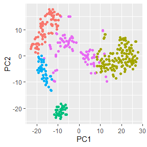

```r
umap_results <- embedding
rownames(umap_results) <- SRR_info[index][index_order]
names(cell.colors) <- SRR_info[index][index_order]
umap_results <- as.data.frame(umap_results)
umap_results$color <- as.factor(cell.colors)

ggplot() +
  geom_point(
    data = umap_results,
    aes(x = V1, y = V2, color = color)
  ) +
  labs(x = "PC1", y = "PC2") +  # Change axis labels
  theme(
    legend.position = "none",
    legend.background = element_blank()
  )
```

```r
arrow.scale=3; cell.alpha=0.4; cell.cex=1; fig.height=4;

vis_umap_Beta_emb_Beta_linear_index  <- show.velocity.on.embedding.cor(umap_results[,1:2],
             res[[3]][["current"]]$M[index_site_name_int_intersect,index],
             res[[3]][["projected"]]$M[index_site_name_int_intersect,index],
             res[[3]][["delta"]]$M[index_site_name_int_intersect,index],
             cell.colors=cell.colors,n=200,scale='log',
             cex=cell.cex,arrow.scale=arrow.scale,arrow.lwd=0.5,rm_uniform="mode1")
```

```
#> delta projections ... log knn ... transition probs ...
#> 'as(<dgeMatrix>, "dgCMatrix")' is deprecated.
#> Use 'as(., "CsparseMatrix")' instead.
#> See help("Deprecated") and help("Matrix-deprecated").
#> done
#> calculating arrows ... done
```

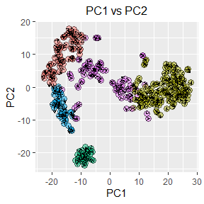

```r
vis_umap_Beta_emb_Beta_linear_index[[1]]
```

```r
arrow.scale=10; cell.alpha=0.4; cell.cex=1; fig.height=4;
vis_umap_Beta_emb_Beta_linear_index_grid <- show.velocity.on.embedding.cor(umap_results[,1:2],
             res[[3]][["current"]]$M[index_site_name_int_intersect,index],
             res[[3]][["projected"]]$M[index_site_name_int_intersect,index],
             res[[3]][["delta"]]$M[index_site_name_int_intersect,index],
             cell.colors=cell.colors,n=200,scale='log',
             cex=cell.cex,arrow.scale=arrow.scale,arrow.lwd=0.5,show.grid.flow = TRUE,grid.n = 20,rm_uniform="mode1")
```

```
#> delta projections ... log knn ... transition probs ... done
#> calculating arrows ... done
#> grid estimates ... grid.sd= 1.79047  min.arrow.size= 0.0358094  max.grid.arrow.length= 0.02634861  done
```

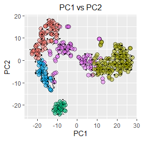

```r
vis_umap_Beta_emb_Beta_linear_index_grid[[1]]
```

## scVelo

jupyter notebook is in figshare: https://doi.org/10.6084/m9.figshare.28955183 or https://github.com/whz991026/VeloRM